# Reproducible Research

This assignment makes use of data from a personal activity monitoring device. This device collects data at 5 minute intervals through out the day. The data consists of two months of data from an anonymous individual collected during the months of October and November, 2012 and include the number of steps taken in 5 minute intervals each day.

# Loading and processing the data

## Loading the data

```r
library(readxl)
Data <- read.csv("activity.csv")
str(Data)
```

```
## 'data.frame':    17568 obs. of  3 variables:
##  $ steps   : int  NA NA NA NA NA NA NA NA NA NA ...
##  $ date    : chr  "2012-10-01" "2012-10-01" "2012-10-01" "2012-10-01" ...
##  $ interval: int  0 5 10 15 20 25 30 35 40 45 ...
```

# What is mean total number of steps taken per day?

```r
library(dplyr)
total.steps <- tapply(Data$steps, Data$date, FUN=sum, na.rm=TRUE)
head(total.steps, n = 5)
```

```
## 2012-10-01 2012-10-02 2012-10-03 2012-10-04 2012-10-05
##          0        126      11352      12116      13294
```

## 1. Histogram

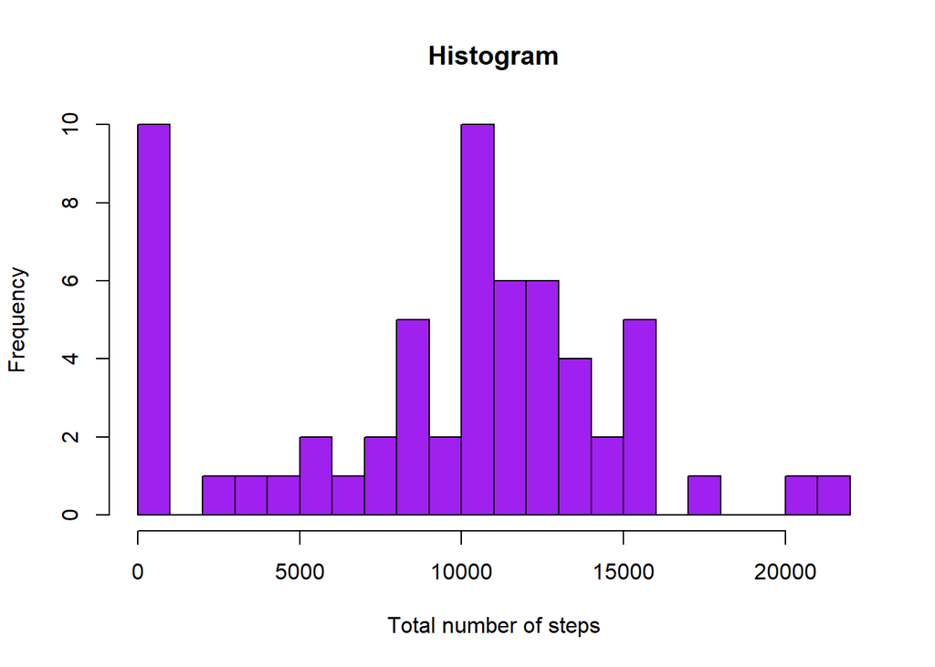

```r
hist(total.steps,
     col = "Purple",
     main = "Histogram",
     xlab = "Total number of steps",
     ylab = "Frequency",
     breaks = 30)
```

```r
steps_Mean <- mean(total.steps, na.rm = TRUE)
steps_Median <- median(total.steps, na.rm = TRUE)
```

# What is the average daily activity pattern?

```r
averages <- aggregate(x = list(steps =  Data$steps),
                      by = list(interval = Data$interval),
                      FUN = mean,
                      na.rm = TRUE)
head(averages, n = 5)
```

```
##   interval     steps
## 1        0 1.7169811
## 2        5 0.3396226
## 3       10 0.1320755
## 4       15 0.1509434
## 5       20 0.0754717
```

## 1. Time series plote

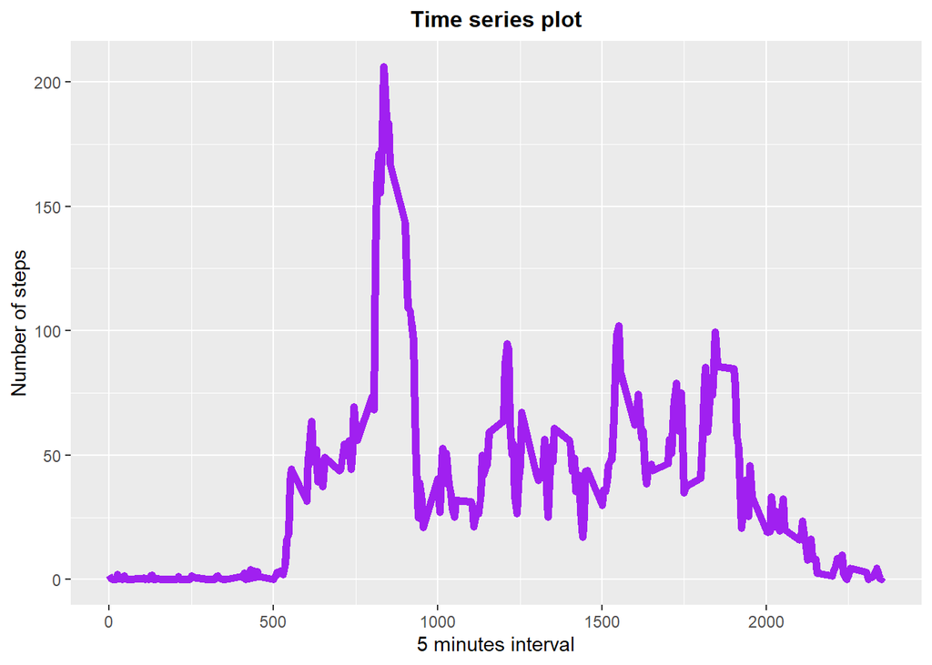

```r
library(ggplot2)
ggplot(data = averages, aes(x = interval, y = steps)) +
  geom_line(color = "purple", size = 2) +
  labs(title = "Time series plot") +
  theme(plot.title = element_text(hjust = 0.5, face = "bold", size = 12)) +
  xlab("5 minutes interval") +
  ylab("Number of steps")
```

## 2. Interval with the maximun number of steps

```r
averages[which.max(averages$steps),]
```

```
##     interval    steps
## 104      835 206.1698
```

# Imputing missing values

here are a number of days/intervals where there are missing values (coded as NA). The presence of missing days may introduce bias into some calculations or summaries of the data

## 1. Total number of missing values

```r
missing_values <- length(which(is.na(Data$steps)))
missing_values
```

```
## [1] 2304
```

## 2. Strategy for filling values in the data set

In order to fill the data set with the missing data we are going to do the following steps:

- Create the variable “interval_steps” in which we fill the missing values with the mean with the R function “apply - tapply”
- Create the variable “Data split” which is the split activity data by intervals
- Fill the missing data for each interval

## 3. New dataset

```r
Interval_steps <- tapply(Data$steps, Data$interval, mean, na.rm = TRUE)
Data_split <- split(Data, Data$interval)
for(i in 1:length(Data_split)){
    Data_split[[i]]$steps[is.na(Data_split[[i]]$steps)] <- Interval_steps[i]
}
activity.imputed <- do.call("rbind", Data_split)
activity.imputed <- activity.imputed[order(activity.imputed$date) ,]
head(activity.imputed, n = 5)
```

```
##          steps       date interval
## 0.1  1.7169811 2012-10-01        0
## 5.2  0.3396226 2012-10-01        5
## 10.3 0.1320755 2012-10-01       10
## 15.4 0.1509434 2012-10-01       15
## 20.5 0.0754717 2012-10-01       20
```